# Ch. 16 Homework

AP

3/28/2022

## HDIW Question 1

1. Zac’s mean vacation amount is 5; Skylar’s is 6; so, on average, the difference between them is 1 vacation (Skylar takes one more vacation than Zac). The variance of the between-subjects sample is 8.3
2. Zac has a variance of 4; Skylar has a variance of 16.
3. Our answer will be closer to 2, because since Skylar has more variation in vacations, the result will prioritize more of her data.

## HDIW Question 2

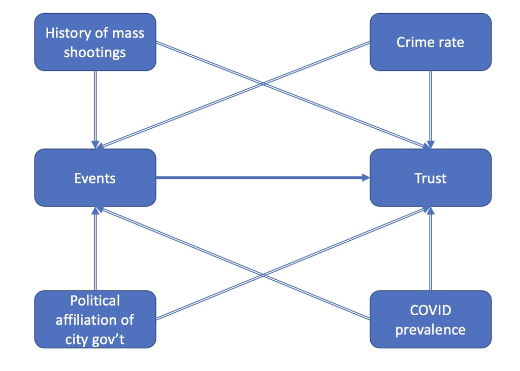

```r
knitr::include_graphics("images/ch16q2.jpg")
```

Political affiliation and history of mass shootings would be controlled under fixed effects, but the other two have the potential to vary over time, so we would have to look closer at them.

## HDIW Question 3

1. within
2. between
3. between
4. between
5. within
6. both

## HDIW Question 4

It effectively standardizes the data, so that we can look at differences in Y given a deviation of X from the mean - whatever that mean is, and however variable those deviations are. It makes 0 the ‘norm’ for an individual, rather than an absolute number.

## HIIP Question 1

Accounting for city-level fixed effects, in a year where a given city has 1 more event than normal, its trust levels will be 3.6 points higher than normal on average.

## HIIP Question 2

Accounting for city- and year-level fixed effects, in a given city in a given year, 1 more event than normal will correspond to a trust level that is 2.4 points higher than normal.

## HIIP Question 3

If the researcher included a linear control variable for time, they would have to assume that the effect of time was linear, whereas including time as a fixed effect can allow them to isolate the independent effects of various time periods. Basically, it deals better with weird time periods (like the 2009 earnings example in the book). I think?

## HIIP Question 4

C

## Coding Question 1

```r
mp <- read.csv("https://raw.githubusercontent.com/NickCH-K/TheEffectAssignments/main/mathpnl.csv")

mp <- mp |>
  select(distid, year, math4, expp, lunch)
```

## Coding Question 2

```r
length(unique(mp$distid))
```

```
## [1] 550
```

```r
length(unique(mp$year))
```

```
## [1] 7
```

## Coding Question 3

```r
mp |>
  group_by(year) |>
  summarize(uniquen = length(unique(distid)))
```

```
## # A tibble: 7 × 2
##    year uniquen
##   <int>   <int>
## 1  1992     550
## 2  1993     550
## 3  1994     550
## 4  1995     550
## 5  1996     550
## 6  1997     550
## 7  1998     550
```

## Coding Question 4

```r
m1 <- lm(math4 ~ expp + lunch,
         data = mp)
summary(m1)
```

```
##
## Call:
## lm(formula = math4 ~ expp + lunch, data = mp)
##
## Residuals:
##     Min      1Q  Median      3Q     Max
## -72.401 -10.484   0.108  10.453  60.454
##
## Coefficients:
##               Estimate Std. Error t value            Pr(>|t|)
## (Intercept) 29.5273165  1.1391190   25.92 <0.0000000000000002 ***
## expp         0.0069223  0.0001995   34.70 <0.0000000000000002 ***
## lunch       -0.3806213  0.0158601  -24.00 <0.0000000000000002 ***
## ---
## Signif. codes:  0 '***' 0.001 '**' 0.01 '*' 0.05 '.' 0.1 ' ' 1
##
## Residual standard error: 15.14 on 3847 degrees of freedom
## Multiple R-squared:  0.3078, Adjusted R-squared:  0.3075
## F-statistic: 855.4 on 2 and 3847 DF,  p-value: < 0.00000000000000022
```

## Coding Question 5

```r
mp <- mp |>
  group_by(distid) |>
  mutate(math4_demean = (math4 - mean(math4)),
         expp_demean = (expp - mean(expp)),
         lunch_demean = (lunch - mean(lunch))) |>
  ungroup()

m2 <- lm(math4_demean ~ expp_demean + lunch_demean,
         data = mp)
summary(m2)
```

```
##
## Call:
## lm(formula = math4_demean ~ expp_demean + lunch_demean, data = mp)
##
## Residuals:
##     Min      1Q  Median      3Q     Max
## -87.389  -6.438  -0.039   6.207  71.351
##
## Coefficients:
##                           Estimate            Std. Error t value
## (Intercept)  0.0000000000000006117 0.1660009352323996434   0.000
## expp_demean  0.0120310216066545003 0.0002138500594724126  56.259
## lunch_demean 0.3135149209294583739 0.0502528745981535505   6.239
##                          Pr(>|t|)
## (Intercept)                     1
## expp_demean  < 0.0000000000000002 ***
## lunch_demean       0.000000000489 ***
## ---
## Signif. codes:  0 '***' 0.001 '**' 0.01 '*' 0.05 '.' 0.1 ' ' 1
##
## Residual standard error: 10.3 on 3847 degrees of freedom
## Multiple R-squared:  0.4989, Adjusted R-squared:  0.4987
## F-statistic:  1915 on 2 and 3847 DF,  p-value: < 0.00000000000000022
```

## Coding Question 6

```r
mpshort <- mp |>
  head(500) |>
  select(distid, math4, expp, lunch)

mpshort$distid <- as.factor(mpshort$distid)
mpdummy <- as.data.frame(model.matrix(~ distid + math4 + expp + lunch + 0, data = mpshort))

m3 <- lm(math4 ~ . -distid1010,
   data=mpdummy)
summary(m3)
```

```
##
## Call:
## lm(formula = math4 ~ . - distid1010, data = mpdummy)
##
## Residuals:
##     Min      1Q  Median      3Q     Max
## -77.612  -7.529  -0.009   6.905  62.630
##
## Coefficients:
##                Estimate  Std. Error t value             Pr(>|t|)
## (Intercept) -29.6590783   8.7846585  -3.376             0.000802 ***
## distid2010  -12.8879059   7.0489314  -1.828             0.068196 .
## distid2020  -38.5196544   7.4966971  -5.138          0.000000423 ***
## distid2070   30.6091348   7.3414083   4.169          0.000037017 ***
## distid2080   -1.4666536   6.8970278  -0.213             0.831702
## distid3000   31.4463925   7.7646263   4.050          0.000060868 ***
## distid3010   32.0520984   8.3526451   3.837             0.000143 ***
## distid3020   38.6608643   7.8062911   4.953          0.000001058 ***
## distid3030   26.2832218   7.6115577   3.453             0.000610 ***
## distid3040   34.5786957   7.8940712   4.380          0.000014935 ***
## distid3050    1.2430582   7.0538318   0.176             0.860201
## distid3060   15.5960035   7.2547993   2.150             0.032137 *
## distid3070   25.2889233   7.8089184   3.238             0.001296 **
## distid3080   11.4043721   7.9399830   1.436             0.151645
## distid3100   38.5346519   8.7272332   4.415          0.000012794 ***
## distid3440   48.6522448  10.2654898   4.739          0.000002926 ***
## distid4000   14.6409064   6.9586776   2.104             0.035966 *
## distid4010   18.4423832   7.0557798   2.614             0.009271 **
## distid5010  -34.1619823   7.0105638  -4.873          0.000001554 ***
## distid5035   11.5116176   7.0677965   1.629             0.104107
## distid5040   36.1782572   7.6617233   4.722          0.000003175 ***
## distid5060   33.8871883   7.6200291   4.447          0.000011118 ***
## distid5065   12.2009238   7.0998343   1.718             0.086436 .
## distid5070    0.9388914   6.9017576   0.136             0.891857
## distid6010  -15.3787905   7.0396284  -2.185             0.029462 *
## distid6020   16.4756663   7.0031288   2.353             0.019096 *
## distid6050    9.0369820   6.9696485   1.297             0.195464
## distid7010  -12.4549201   7.6729074  -1.623             0.105279
## distid7040   -1.2219777   6.9095465  -0.177             0.859707
## distid8010   24.9964308   7.2110803   3.466             0.000581 ***
```

[output cut: 35 more lines]

```
## distid13110  35.6648790   8.3201951   4.287          0.000022463 ***
## distid13120  29.1802028   8.2100475   3.554             0.000422 ***
## distid13130  16.8000537   6.9724671   2.409             0.016398 *
## distid13135  21.9505323   7.1797188   3.057             0.002374 **
## distid14010   2.7404170   6.9542447   0.394             0.693731
## distid14020  17.0680687   6.9230691   2.465             0.014080 *
## distid14030  15.1367846   9.3779912   1.614             0.107252
## expp          0.0088387   0.0006554  13.486 < 0.0000000000000002 ***
## lunch         0.8007286   0.1932727   4.143          0.000041359 ***
## ---
## Signif. codes:  0 '***' 0.001 '**' 0.01 '*' 0.05 '.' 0.1 ' ' 1
##
## Residual standard error: 12.9 on 426 degrees of freedom
## Multiple R-squared:  0.551,  Adjusted R-squared:  0.4741
## F-statistic: 7.162 on 73 and 426 DF,  p-value: < 0.00000000000000022
```

```r
lht(m3, matchCoefs(m3, "distid"))
```

```
## Linear hypothesis test
##
## Hypothesis:
## distid2010 = 0
## distid2020 = 0
## distid2070 = 0
## distid2080 = 0
## distid3000 = 0
## distid3010 = 0
## distid3020 = 0
## distid3030 = 0
## distid3040 = 0
## distid3050 = 0
## distid3060 = 0
## distid3070 = 0
## distid3080 = 0
## distid3100 = 0
## distid3440 = 0
## distid4000 = 0
## distid4010 = 0
## distid5010 = 0
## distid5035 = 0
## distid5040 = 0
## distid5060 = 0
## distid5065 = 0
## distid5070 = 0
## distid6010 = 0
## distid6020 = 0
## distid6050 = 0
## distid7010 = 0
## distid7040 = 0
## distid8010 = 0
## distid8030 = 0
## distid8050 = 0
## distid9010 = 0
## distid9030 = 0
## distid9050 = 0
## distid9090 = 0
## distid10015 = 0
## distid10025 = 0
```

[output cut: 43 more lines]

```
##     distid9050 + distid9090 + distid10015 + distid10025 + distid11000 +
##     distid11010 + distid11020 + distid11030 + distid11033 + distid11160 +
##     distid11200 + distid11210 + distid11240 + distid11250 + distid11300 +
##     distid11310 + distid11320 + distid11330 + distid11340 + distid11670 +
##     distid12010 + distid12020 + distid12040 + distid13000 + distid13010 +
##     distid13020 + distid13050 + distid13070 + distid13080 + distid13090 +
##     distid13095 + distid13110 + distid13120 + distid13130 + distid13135 +
##     distid14010 + distid14020 + distid14030 + expp + lunch) -
##     distid1010
##
##   Res.Df    RSS Df Sum of Sq      F                Pr(>F)
## 1    497 122535
## 2    426  70858 71     51677 4.3759 < 0.00000000000000022 ***
## ---
## Signif. codes:  0 '***' 0.001 '**' 0.01 '*' 0.05 '.' 0.1 ' ' 1
```

```r
# null rejected
```

## Coding Question 7

```r
m4 <- feols(math4 ~ expp + lunch | distid,
      data = mp,
      vcov = "cluster")

summary(m4)
```

```
## OLS estimation, Dep. Var.: math4
## Observations: 3,850
## Fixed-effects: distid: 550
## Standard-errors: Clustered (distid)
##       Estimate Std. Error  t value   Pr(>|t|)
## expp  0.012031   0.000486 24.73496  < 2.2e-16 ***
## lunch 0.313515   0.094000  3.33527 0.00090972 ***
## ---
## Signif. codes:  0 '***' 0.001 '**' 0.01 '*' 0.05 '.' 0.1 ' ' 1
## RMSE: 10.3     Adj. R2: 0.626328
##              Within R2: 0.498917
```

## Coding Question 8

```r
m5 <- feols(math4 ~ expp + lunch | distid + year,
      data = mp,
      vcov = "cluster")

summary(m5)
```

```
## OLS estimation, Dep. Var.: math4
## Observations: 3,850
## Fixed-effects: distid: 550,  year: 7
## Standard-errors: Clustered (distid)
##        Estimate Std. Error   t value Pr(>|t|)
## expp  -0.000168   0.000710 -0.236864  0.81285
## lunch  0.018441   0.100154  0.184125  0.85398
## ---
## Signif. codes:  0 '***' 0.001 '**' 0.01 '*' 0.05 '.' 0.1 ' ' 1
## RMSE: 8.2812     Adj. R2: 0.757827
##                Within R2: 9.976e-5
```

## Coding Question 9

```r
models <- list()
models[["OLS"]] <- m1
models[["Demean"]] <- m2
models[["Dummy"]] <- m3
models[["FixEst"]] <- m4
models[["TwoWay FixEst"]] <- m5


msummary(models,
         coef_map = c("expp", "expp_demean", "lunch", "lunch_demean"),
         gof_omit = ".*",
         stars = TRUE)
```

|  | OLS | Demean | Dummy | FixEst | TwoWay FixEst |
| --- | --- | --- | --- | --- | --- |
| expp | 0.007*** |  | 0.009*** | 0.012*** | 0.000 |
|  | (0.000) |  | (0.001) | (0.000) | (0.001) |
| expp_demean |  | 0.012*** |  |  |  |
|  |  | (0.000) |  |  |  |
| lunch | −0.381*** |  | 0.801*** | 0.314*** | 0.018 |
|  | (0.016) |  | (0.193) | (0.094) | (0.100) |
| lunch_demean |  | 0.314*** |  |  |  |
|  |  | (0.050) |  |  |  |

+ p < 0.1, * p < 0.05, ** p < 0.01, *** p < 0.001

It’s interesting that the “Demean” and “FixEst” columns are identical; it’s interesting (and a bit worrying) that the “Dummy” column doesn’t match them. That might mean that I did something wrong…

## Coding Question 10

```r
mp <- mp |>
  group_by(distid) |>
  mutate(math4_demean = (math4 - mean(math4)),
         expp_demean = (expp - mean(expp)),
         lunch_demean = (lunch - mean(lunch)),
         expp_mean = mean(expp),
         lunch_mean = mean(lunch),
         distid = factor(distid)) |>
  ungroup()

m6 <- lmer(math4 ~ expp_demean + lunch_demean + expp_mean + lunch_mean + (1 | distid),
         data = mp)
summary(m6)
```

```
## Linear mixed model fit by REML ['lmerMod']
## Formula: math4 ~ expp_demean + lunch_demean + expp_mean + lunch_mean +
##     (1 | distid)
##    Data: mp
##
## REML criterion at convergence: 30287
##
## Scaled residuals:
##     Min      1Q  Median      3Q     Max
## -7.9152 -0.5961  0.0061  0.5836  6.3543
##
## Random effects:
##  Groups   Name        Variance Std.Dev.
##  distid   (Intercept)  54.96    7.413
##  Residual             123.75   11.124
## Number of obs: 3850, groups:  distid, 550
##
## Fixed effects:
##                Estimate Std. Error t value
## (Intercept)  57.0350106  2.2281622  25.597
## expp_demean   0.0120310  0.0002310  52.090
## lunch_demean  0.3135149  0.0542746   5.776
## expp_mean     0.0019855  0.0003995   4.970
## lunch_mean   -0.4413807  0.0242230 -18.222
##
## Correlation of Fixed Effects:
##             (Intr) expp_d lnch_d expp_m
## expp_demean  0.000
## lunch_demen  0.000 -0.323
## expp_mean   -0.941  0.000  0.000
## lunch_mean  -0.303  0.000  0.000  0.007
```